# Data Visualisation in Python

This is a HTML document. The Introduction to Python course is written and intended to be used in a Jupyter Notebook file. These HTML documents have been made available for users who require screen readers or other accessibility needs. These HTML documents have been tested, but if you notice any errors or any compatibility issues please contact us on the GSS Capability email inbox.

If you are using a screen reader you will need to set your punctuation level (sometimes called verbosity) to full, especially for the code sections.

# Chapter 6b – Presenting Tables in Python (Using Matplotlib)

## Chapter Overview

- Packages and Data
- Creating a Basic Table
- Customising Fonts
- Setting Cell Height, Padding and Width
- Column Headers
- Setting Titles, Subtitles and Captions
- GSS Styling
- Grouping a column
- Exporting Tables

Creating effective presentation data tables can be a very important element of data visualisation.

Unfortunately, makers of Python packages don’t seem to agree! Presentation tables are often given as an afterthought in packages such as Pandas and Matplotlib; with functionality designed to be “good enough” and for users to build and create their own extensible packages to build on the functionality; no one has of yet taken up that mantle.

We recommend using toyplot (covered in chapter 5a) - but this chapter covers creating tables using Matplotlib if you are unable to use that package.

At the time of writing this course (2020) we’re unable to find any majorly satisfactory solution that outputs a table following all of the elements of the [ONS and GSS Style Guide](https://style.ons.gov.uk/category/data-visualisation/tables/).

This section of the course will attempt to get as close as possible to the desired outcome using Matplotlib’s .table() method.

If correctly formatting tables is an important element of your data visualisation I recommend looking into presenting your data using R, which has more functionality for presentation tables. The companion course “Data Visualisation in R” also contains a tables section which covers this in detail.

# 1 Packages and Data

Let’s start, as always by loading our packages and our data.

We’re using:

- Numpy – Version 1.12.1
- Pandas – Version 0.20.1
- Matplotlib – Version 2.0.2 (here as the pyplot module)
- Seaborn - Version 0.7.1

Remember you can use the .__version__ attribute (e.g np.__version__ ) to check your version.

More information about the packages is given in Chapter 1.

We’re following standard convention for nicknames, and we’ll also load the gapminder data.

```python
import pandas as pd
import matplotlib as mpl
import matplotlib.pyplot as plt
from matplotlib.font_manager import FontProperties

# uncomment the below line in Jupyter Notebook
# %matplotlib inline
```

The magic command %matplotlib inline lowers the resolution of our images when displayed in the notebook; this helps with speed, especially on larger images but is very noticeable when we’re working with tables as they’re text based objects as it makes them look pixelated.

We can use the rcParams to raise the DPI (dots per inch) of the outputs in the notebook. Note this may mean they take slightly longer to render. To reduce this behaviour lower the DPI.

This will also work for other visualisations; we’ve not applied this before due to efficiency and speed of rendering the notebooks with large amounts of visualisations.

It’s also important to note that this needs to be in a new cell. %matplotlib inline appears to behave asynchronously and action last; overwriting the effects of the rcParams - so it needs to be in its own cell.

```python
mpl.rcParams["figure.dpi"]= 300 # Set the DPI for outputs to 300
```

We’ll also load in our data.

```python
gapminder = pd.read_csv("../data/gapminder.csv") # Read in the Data
```

# 2 Creating a Basic Table

We’re going to use the gapminder data and we’re going to prepare it before we start.

As with other visualisations data preparation is a really important step.

With the .table() method we need to have our data mostly formatted before we visualise it.

Here I’m manipulating my data so that I have the population data for 3 years (1997, 2002 and 2007) for the first five countries in each continent – apart from Oceania, which only comprises of 2 countries in our dataset.

```python
select_countries_3y_pop = (gapminder[gapminder["year"].isin([1997, 2002, 2007])] # Filter for the years
                           .filter(["country", "continent", "year", "pop"]) # .filter *selects* columns
                           .astype({"pop": "int64"}) # Supresses the Scientific Notation of the year columns
                           .pivot_table(index = ["continent","country"],
                                        columns = "year", values = "pop") # Make the data "wider" so each year is a col
                           .reset_index() # Reset our index; so we don't have a multi index
                           .groupby("continent").head()) # Group by the continent and return the first 5 rows for each continent.

select_countries_3y_pop.columns.name = None #Removed the "year" label on the index

# View the new DataFrame
select_countries_3y_pop
```

```
    continent                 country        1997        2002        2007
0      Africa                 Algeria    29072015    31287142    33333216
1      Africa                  Angola     9875024    10866106    12420476
2      Africa                   Benin     6066080     7026113     8078314
3      Africa                Botswana     1536536     1630347     1639131
4      Africa            Burkina Faso    10352843    12251209    14326203
52   Americas               Argentina    36203463    38331121    40301927
53   Americas                 Bolivia     7693188     8445134     9119152
54   Americas                  Brazil   168546719   179914212   190010647
55   Americas                  Canada    30305843    31902268    33390141
56   Americas                   Chile    14599929    15497046    16284741
77       Asia             Afghanistan    22227415    25268405    31889923
78       Asia                 Bahrain      598561      656397      708573
79       Asia              Bangladesh   123315288   135656790   150448339
80       Asia                Cambodia    11782962    12926707    14131858
81       Asia                   China  1230075000  1280400000  1318683096
110    Europe                 Albania     3428038     3508512     3600523
111    Europe                 Austria     8069876     8148312     8199783
112    Europe                 Belgium    10199787    10311970    10392226
113    Europe  Bosnia and Herzegovina     3607000     4165416     4552198
114    Europe                Bulgaria     8066057     7661799     7322858
140   Oceania               Australia    18565243    19546792    20434176
141   Oceania             New Zealand     3676187     3908037     4115771
```

We can create a table using the code below.

We can create the table directly from a pandas DataFrame by passing the dataframe.values attribute to cellText and our column titles to the attribute to colLabels.

Column titles here have been manually set so continent and country will have capital letters.

To keep column headers exactly as they are in the DataFrame colLabels can be set:

colLabels = DataFrame.columns

Or if they were all purely text values and just the first letter needed to be capitalised the str.title method could be used: colLables = DataFrame.columns.str.title()

This won’t work here as 1997 etc will be returned as NaN.

The additional parameters loc has been set to control the location of the table and edges to draw a grid around the cells. Matplotlib automatically generates an axis; to remove that use axes.axis(‘off’) and figure.tight_layout() will reduce the amount of white space around the table.

```python
figure, axes = plt.subplots(figsize = (8,5)) # Set up our figure and axis

axes.axis("off") # Removes the axis from the figure
```

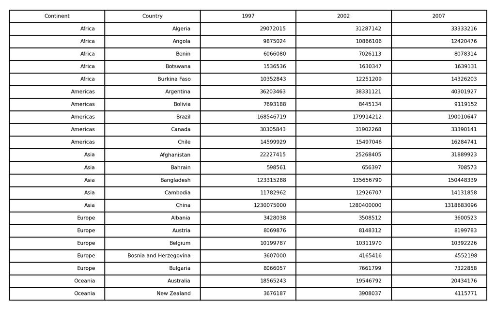

```python
table = axes.table(cellText=select_countries_3y_pop.values, # Values we want in the cells
                   colLabels=["Continent", "Country", "1997", "2002", "2007"], # Our column headers
                   loc="center", # Where we want our table located
                   edges="closed" ) # Draws a grid around the cells

figure.tight_layout() # Controls the amount of white space around the table

plt.show();
```

# 3 Customising Fonts

We can customise our table through the use of table.properties() and looping over the children objects that make up our table cells.

Unfortunately the only way to change elements is to loop through each cell in our table and set values individually. As said before this isn’t necessarily the most elegant of solutions – however there’s no “simple” inbuilt method.

Here the font size, colour, and name is being set to match GSS standards.

The cell contents are also being aligned to the right. There is a parameter within axes.table() to do this as well (cellLoc=“right”) however this only applies to cells, rather than both cells and colLabels.

```python
figure, axes = plt.subplots(figsize = (8,5)) # Set up our figure and axis

axes.axis("off") # Removes the axis from the figure
```

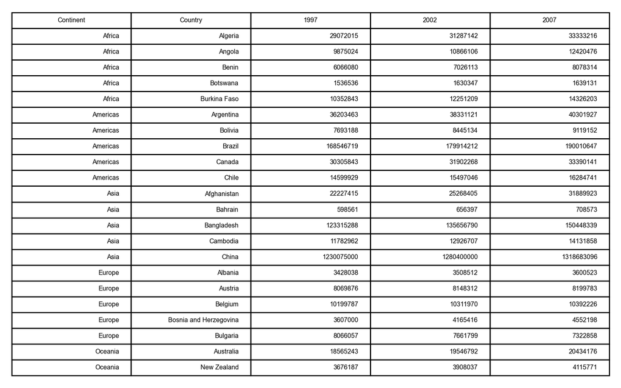

```python
table = axes.table(cellText=select_countries_3y_pop.values, # Values we want in the cells
                   colLabels=["Continent", "Country", "1997", "2002", "2007"] , # Our column headers
                   loc="center", # Where we want our table located
                   edges="closed") # Draws a grid around the cells


# Customise the cell contents

# Create our items to loop through
table_props = table.properties()
table_cells = table_props["children"]

for cell in table_cells:
    cell.get_text().set_fontsize(14) # Size in points
    cell.get_text().set_color("black") # Colour
    cell.get_text().set_fontname("Arial") # Font name
    cell._loc = "right" # ensure contents (incl headers) are aligned right

figure.tight_layout() # Controls the amount of white space around the table

plt.show()
```

# 4 Setting Cell Height, Padding and Width

The cell height and the cell width of the table may need to be adjusted.

Despite being right aligned we have a large gap between the numbers and the border of the cell. By default Matplotlib uses 10% padding, but this is too much, and cell.PAD can be set to adjust it.

```python
figure, axes = plt.subplots(figsize = (8,5)) # Set up our figure and axis

axes.axis("off") # Removes the axis from the figure
```

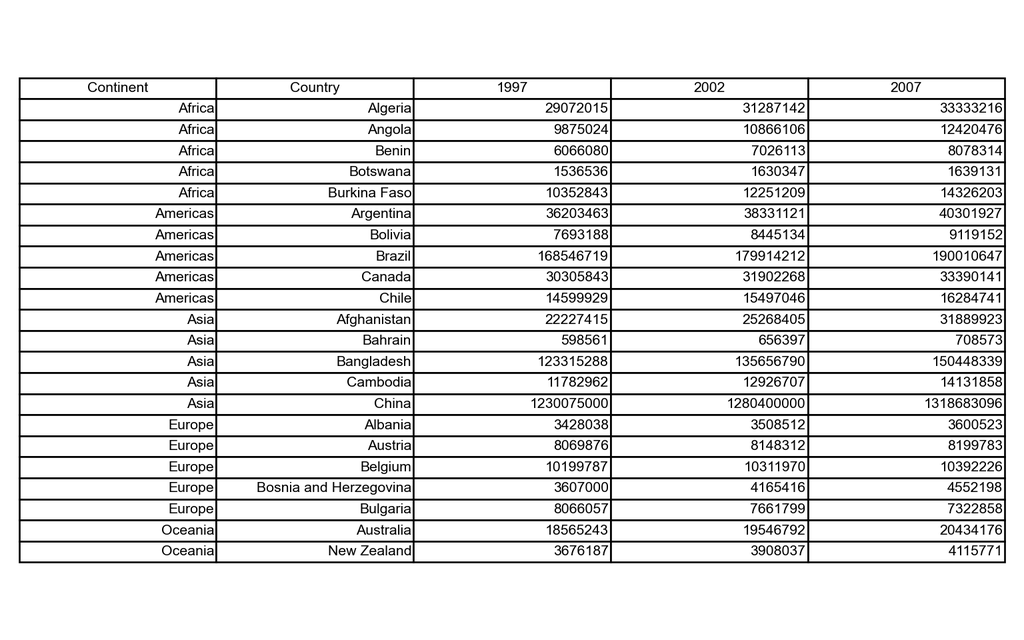

```python
table = axes.table(cellText=select_countries_3y_pop.values, # Values we want in the cells
                   colLabels=["Continent", "Country", "1997", "2002", "2007"] , # Our column headers
                   loc="center", # Where we want our table located
                   edges="closed") # Draws a grid around the cells

# Customise the cell contents

# Create our items to loop through
table_props = table.properties()
table_cells = table_props["children"]

for cell in table_cells:
    cell.get_text().set_fontsize(14) # Size in points
    cell.get_text().set_color("black") # Colour
    cell.get_text().set_fontname("Arial") # Font name
    cell._loc = "right" # ensure contents (incl headers) are aligned right
    cell.set_height(0.07) # Set height of cells
    cell.PAD = 0.01 # Adjust padding between data and border of cell.

figure.tight_layout() # Controls the amount of white space around the table

plt.show()
```

To control the width of cells a separate loop with the .auto_set_column_width() method can be used. In some versions of Matplotlib this can be run on its own; others will require it to be looped over each column in the table.

Note this loop comes above the one with cell.PAD and that the cell padding needed to be adjusted to get the desired output.

```python
figure, axes = plt.subplots(figsize = (8,5)) # Set up our figure and axis


axes.axis("off") # Removes the axis from the figure
```

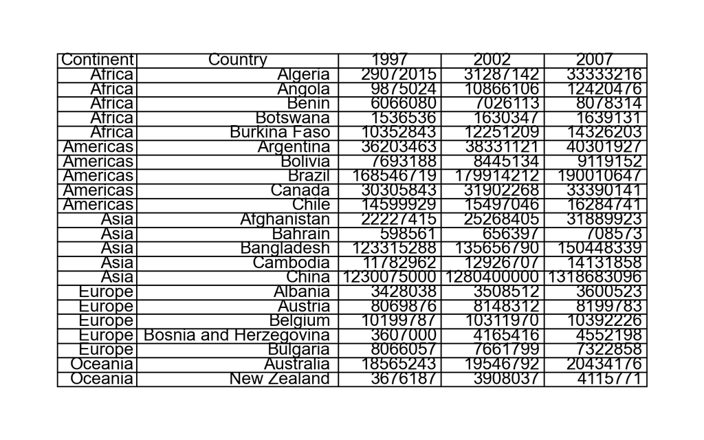

```python
table = axes.table(cellText=select_countries_3y_pop.values, # Values we want in the cells
                   colLabels=["Continent", "Country", "1997", "2002", "2007"] , # Our column headers
                   loc="center", # Where we want our table located
                   edges="closed") # Draws a grid around the cells

# Loop over each column and auto set the width

for each_column in range(len(select_countries_3y_pop.columns)):
    table.auto_set_column_width(each_column)

# Customise the cell contents
# Create our items to loop through
table_props = table.properties()
table_cells = table_props["children"]

for cell in table_cells:
    cell.get_text().set_fontsize(14) # Size in points
    cell.get_text().set_color("black") # Colour
    cell.get_text().set_fontname("Arial") # Font name
    cell._loc = "right" # ensure contents (incl headers) are aligned right
    cell.set_height(0.07) # Set height of cells
    cell.PAD = 0.04 # Adjust padding between data and border of cell.

figure.tight_layout() # Controls the amount of white space around the table

plt.show()
```

# 5 Column Headers

```python
figure, axes = plt.subplots(figsize = (8,5)) # Set up our figure and axis

axes.axis("off") # Removes the axis from the figure
```

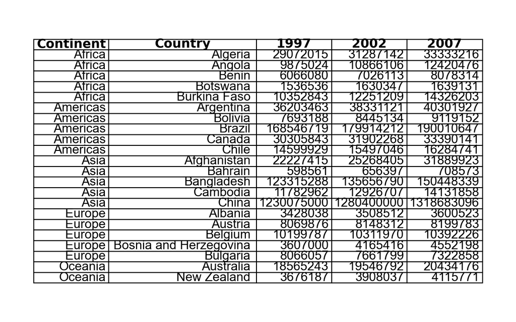

```python
table = axes.table(cellText=select_countries_3y_pop.values, # Values we want in the cells
                   colLabels=["Continent", "Country", "1997", "2002", "2007"] , # Our column headers
                   loc="center", # Where we want our table located
                   edges="closed") # Draws a grid around the cells

# Loop over each column and auto set the width
for each_column in range(len(select_countries_3y_pop.columns)):
    table.auto_set_column_width(each_column)

# Customise the cell contents
# Create our items to loop through
table_props = table.properties()
table_cells = table_props["children"]

for cell in table_cells:
        cell.get_text().set_fontsize(14) # Size in points
        cell.get_text().set_color("black") # Colour
        cell.get_text().set_fontname("Arial") # Font name
        cell._loc = "right" # ensure contents (incl headers) are aligned right
        cell.set_height(0.07) # Set height of cells
        cell.PAD = 0.04 # Adjust padding between data and border of cell.

# Create a custom header row with larger font and bigger text
for (row, col), cell in table.get_celld().items():
    if (row == 0) or (col == -1):
        cell.set_text_props(fontproperties=FontProperties(weight="bold", size = 14))
        # Note this uses from matplotlib.font_manager import FontProperties - that we imported at the top

figure.tight_layout() # Controls the amount of white space around the table

plt.show()
```

# 6 Setting Titles, Subtitles and Captions

As usual with these methods you may have to play around with the position of the X and Y co-ordinates to gain the result desired.

```python
figure, axes = plt.subplots(figsize = (8,5)) # Set up our figure and axis

axes.axis("off") # Removes the axis from the figure
```

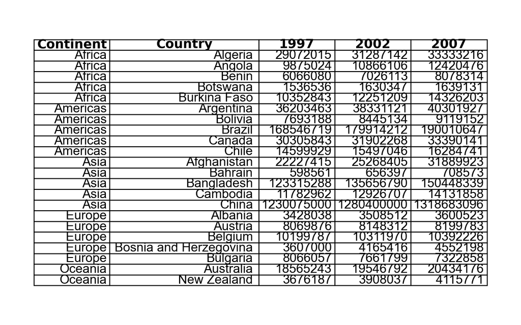

```python
table = axes.table(cellText=select_countries_3y_pop.values, # Values we want in the cells
                   colLabels=["Continent", "Country", "1997", "2002", "2007"] , # Our column headers
                   loc="center", # Where we want our table located
                   edges="closed") # Draws a grid around the cells

# Create Titles, Subtitles and Caption
title = "Table 1: Population of select countries over three years"
plt.figtext(x=0.08, y=1.3,  s=title, ha="left", fontweight="bold", fontsize=16, fontname="sans-serif")

subtitle = "Population for 1997, 2002 and 2007"
plt.figtext(x=0.08, y=1.25, s=subtitle, ha="left", fontweight="light", fontsize=14, fontname="sans-serif")

caption = "Source: Gapminder.org"
plt.figtext(x=0.95, y=-0.25, s=caption, ha="right", fontweight="light", fontsize=12, fontname="sans-serif")


# Loop over each column and auto set the width
for each_column in range(len(select_countries_3y_pop.columns)):
    table.auto_set_column_width(each_column)

# Customise the cell contents
# Create our items to loop through
table_props = table.properties()
table_cells = table_props["children"]
# Loop through the cells
for cell in table_cells:
    cell.get_text().set_fontsize(14) # Size in points
    cell.get_text().set_color("black") # Colour
    cell.get_text().set_fontname("Arial") # Font name
    cell._loc = "right" # ensure contents (incl headers) are aligned right
    cell.set_height(0.07) # Set height of cells
    cell.PAD = 0.04 # Adjust padding between data and border of cell.

# Create a custom header row with larger font and bigger text
for (row, col), cell in table.get_celld().items():
    if (row == 0) or (col == -1):
        cell.set_text_props(fontproperties=FontProperties(weight="bold", size = 14))
        # Note this uses from matplotlib.font_manager import FontProperties - that we imported at the top

figure.tight_layout() # Controls the amount of white space around the table

plt.show()
```

# 7 GSS Styling

As said above this isn’t exactly following the GSS guidelines; but is **reasonably** close.

The cell below expands on the loop that changes the header row. Here we now control the colour of the header row and set the line width to 0. Setting the line width to zero effectively “hides” the edges of the cells. In axes.table() the parameter edges can be set to open, however if the edges are open they can’t be coloured – so they can be “hidden” by setting the width to 0.

N.B - This doesn’t work for all versions of Matplotlib; and there doesn’t appear to be a suitable way to make this work. Suggestions are to experiment with the .annotate() method. If you come up with a better solution please let us know!

```python
figure, axes = plt.subplots(figsize = (8,5)) # Set up our figure and axis

axes.axis("off") # Removes the axis from the figure

# Fix the axis - the horizontal line goes wandering without this.
```

```python
axes.axis([0, select_countries_3y_pop.shape[1], select_countries_3y_pop.shape[0],-1])
```

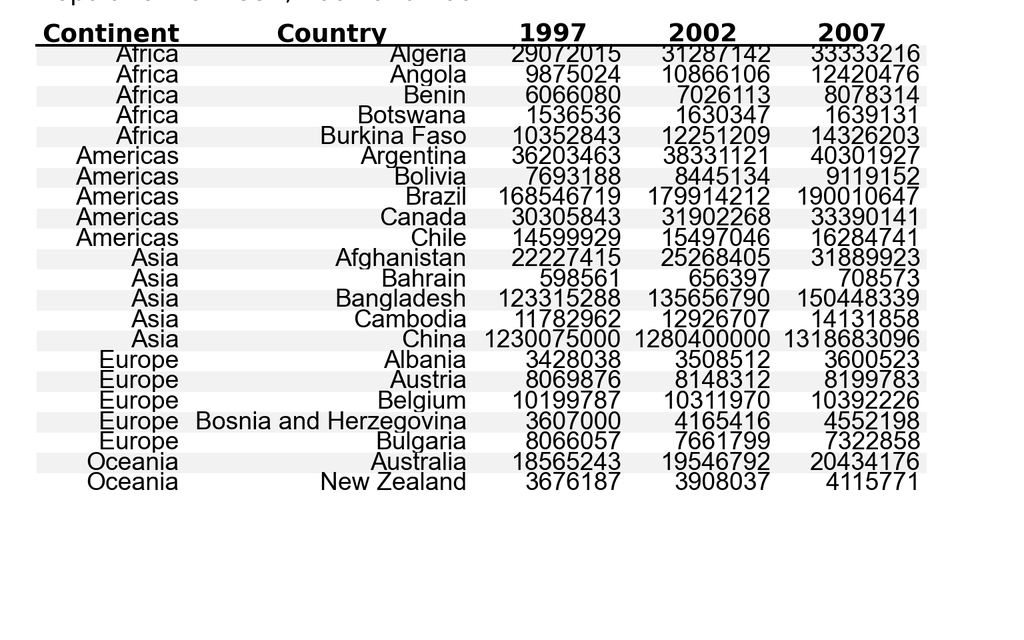

```python
table = axes.table(cellText=select_countries_3y_pop.values, # Values we want in the cells
                   colLabels=["Continent", "Country", "1997", "2002", "2007"] , # Our column headers
                   loc="upper left", # Where we want our table located
                   edges="closed",) # Draws a grid around the cells - If we don't have this we can't colour them!


# Create Titles, Subtitles and Caption
title = "Table 1: Population of select countries over three years"
plt.figtext(x=0.04, y=1.1, s=title, ha="left", fontweight="bold", fontsize=16, fontname="sans-serif")

subtitle = "Population for 1997, 2002 and 2007"
plt.figtext(x=0.04, y=1.0, s=subtitle, ha="left", fontweight="light", fontsize=14, fontname="sans-serif")

caption = "Source: Gapminder.org"
plt.figtext(x=0.95, y=-0.55, s=caption, ha="right", fontweight="light", fontsize=12, fontname="sans-serif")

# Loop over each column and auto set the width
for each_column in range(len(select_countries_3y_pop.columns)):
    table.auto_set_column_width(each_column)

# Customise the cell contents
# Create our items to loop through
table_props = table.properties()
table_cells = table_props["children"]
# Loop through the cells
for cell in table_cells:
    cell.get_text().set_fontsize(14) # Size in points
    cell.get_text().set_color("black") # Colour
    cell.get_text().set_fontname("Arial") # Font name
    cell._loc = "right" # ensure contents (incl headers) are aligned right
    cell.set_height(0.07) # Set height of cells
    cell.PAD = 0.04 # Adjust padding between data and border of cell.

# Create a custom header row with larger font and bigger text. Change the colour of the cells,
for (row, col), cell in table.get_celld().items():
    if (row == 0) or (col == -1):
        cell.set_text_props(fontproperties=FontProperties(weight="bold", size = 14))
        # Note this uses from matplotlib.font_manager import FontProperties - that we imported at the top
        cell.set_facecolor("white")
        cell.set_linewidth(0)
    elif (row % 2 == 0):  # Even rows - row number divided by two has a remainder of zero
        cell.set_facecolor("white")
        cell.set_linewidth(0)
    else: # Effectively odd rows
        cell.set_facecolor("#F2F2F2")
        cell.set_linewidth(0)

# Line
plt.axhline(y = 1.08, xmin = 0.02, xmax = 0.96, color = "black")

figure.tight_layout() # Controls the amount of white space around the table

plt.show();
```

# 8 Grouping a column

Often tables will have a “grouped” column. Rather than the first 5 rows having “Africa” in the continent column; only the first would. This can make data slightly easier to read; some people find this more attractive. This can also create the illusion of merged cells – similarly to excel. This solution is one of many ways it could be done; this method avoids multiple indexes which often don’t work well with Matplotlib.

Using the .duplicated() method on the continent column returns a Boolean series; False where it’s the first instance of the value; and True where it’s repeated.

.loc[] can then be used, passing that Boolean series as the lookup; updating the “continent” column and setting the value of the column (where True) to blank.

```python
grouped_continents = select_countries_3y_pop.copy()
grouped_continents.reset_index(inplace = True, drop=True) # Reset the index
duplicate_continents = grouped_continents["continent"].duplicated() # Returns "False" for first item, "True" for subsequent
grouped_continents.loc[duplicate_continents,"continent"] = ""  # Replaces "True" values with blanks
grouped_continents.head(7) # Check it out! Gives the impression of a multilevel index
```

```
  continent       country      1997      2002      2007
0    Africa       Algeria  29072015  31287142  33333216
1                  Angola   9875024  10866106  12420476
2                   Benin   6066080   7026113   8078314
3                Botswana   1536536   1630347   1639131
4            Burkina Faso  10352843  12251209  14326203
5  Americas     Argentina  36203463  38331121  40301927
6                 Bolivia   7693188   8445134   9119152
```

```python
figure, axes = plt.subplots(figsize = (8,5)) # Set up our figure and axis

axes.axis("off") # Removes the axis from the figure

# Fix the axis - the horizontal line goes wandering without this.
```

```python
axes.axis([0, select_countries_3y_pop.shape[1], select_countries_3y_pop.shape[0],-1])
```

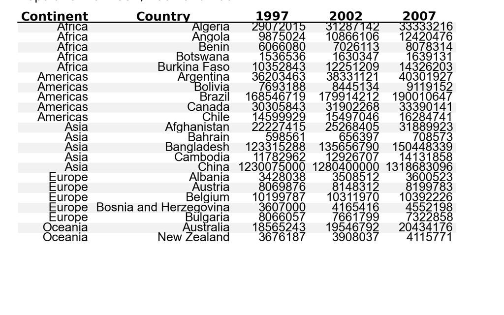

```python
table = axes.table(cellText=select_countries_3y_pop.values, # Values we want in the cells
                   colLabels=["Continent", "Country", "1997", "2002", "2007"] , # Our column headers
                   loc="upper left", # Where we want our table located
                   edges="closed",) # Draws a grid around the cells - If we don't have this we can't colour them!


# Create Titles, Subtitles and Caption
title = "Table 1: Population of select countries over three years"
plt.figtext(x=0.04, y=1.1, s=title, ha="left", fontweight="bold", fontsize=16, fontname="sans-serif")

subtitle = "Population for 1997, 2002 and 2007"
plt.figtext(x=0.04, y=1.0, s=subtitle, ha="left", fontweight="light", fontsize=14, fontname="sans-serif")

caption = "Source: Gapminder.org"
plt.figtext(x=0.95, y=-0.55, s=caption, ha="right", fontweight="light", fontsize=12, fontname="sans-serif")

# Loop over each column and auto set the width
for each_column in range(len(select_countries_3y_pop.columns)):
    table.auto_set_column_width(each_column)

# Customise the cell contents
# Create our items to loop through
table_props = table.properties()
table_cells = table_props["children"]
# Loop through the cells
for cell in table_cells:
    cell.get_text().set_fontsize(14) # Size in points
    cell.get_text().set_color("black") # Colour
    cell.get_text().set_fontname("Arial") # Font name
    cell._loc = "right" # ensure contents (incl headers) are aligned right
    cell.set_height(0.07) # Set height of cells
    cell.PAD = 0.04 # Adjust padding between data and border of cell.

# Create a custom header row with larger font and bigger text. Change the colour of the cells,
for (row, col), cell in table.get_celld().items():
    if (row == 0) or (col == -1):
        cell.set_text_props(fontproperties=FontProperties(weight="bold", size = 14))
        # Note this uses from matplotlib.font_manager import FontProperties - that we imported at the top
        cell.set_facecolor("white")
        cell.set_linewidth(0)
    elif (row % 2 == 0):  # Even rows - row number divided by two has a remainder of zero
        cell.set_facecolor("white")
        cell.set_linewidth(0)
    else: # Effectively odd rows
        cell.set_facecolor("#F2F2F2")
        cell.set_linewidth(0)

# Line
plt.axhline(y = 1.08, xmin = 0.02, xmax = 0.96, color = "black")

figure.tight_layout() # Controls the amount of white space around the table

plt.show();
```

# 9 Exporting Tables

As these tables are Matplotlib objects they can be saved in the same way as other figures. In the cell below is an example; this is the same code as used in Chapter 2 – Plotting Overview. Please feel free to review the code in that section.

```python
figure.savefig("../outputs/my_table.png", dpi=300, bbox_inches="tight")
```

# 10 End of Chapter

You have completed Chapter 6b of Data Visualisation in Python, please continue to Chapter 7 - Case Studies.